# Capstone - Milestone Report

Akbarali Shaikh

9/7/2019

## Synopsis

The captsone project focuses on utilizing data science techniques on the subject of natural language processing. The key task is to create an application using R Shiny to predict the next word given a preceding word or sequence of words. SwiftKey, the corporate sponsor for this project.

## Objective / Motivation

1. Demonstrate that you’ve downloaded the data and have successfully loaded it in.
2. Create a basic report of summary statistics about the data sets.
3. Report any interesting findings that you amassed so far.
4. Get feedback on your plans for creating a prediction algorithm and Shiny app.

## Review criteria

1. Does the link lead to an HTML page describing the exploratory analysis of the training data set?
2. Has the data scientist done basic summaries of the three files? Word counts, line counts and basic data tables?
3. Has the data scientist made basic plots, such as histograms to illustrate features of the data?
4. Was the report written in a brief, concise style, in a way that a non-data scientist manager could appreciate?

## Load Packages

```r
# Loading required libraries
library(tm);
```

```r
library(ngram);
library(wordcloud);
library(ggplot2)
library(quanteda)
```

## Read and loading text file

```r
En_Twit_text <- readLines("./data/en_US/en_US.twitter.txt", encoding = "UTF-8", skipNul=TRUE)
En_US_blogs_text <- readLines("./data/en_US/en_US.blogs.txt", encoding = "UTF-8", skipNul=TRUE)
En_US_NEWS_text <- readLines("./data/en_US/en_US.news.txt", encoding = "UTF-8", skipNul=TRUE)
```

```r
#Random Sampling from the three text files to be used for model building

twitter_sample = sample(En_Twit_text, length(En_Twit_text)*0.015, replace = FALSE)
news_sample = sample(En_US_NEWS_text, length(En_US_NEWS_text)*0.015, replace = FALSE)
blogs_sample = sample(En_US_blogs_text, length(En_US_blogs_text)*0.015, replace = FALSE)

# Creating a corpus for text mining and pre-processing
sample_files = c(twitter_sample,news_sample,blogs_sample)
files = Corpus(VectorSource(sample_files))

df.nwords.all <- data.frame(nword = c(twitter_sample, news_sample, blogs_sample),
  type = c(rep("blog", length(blogs_sample)), rep("twitter",length(twitter_sample)),
           rep("web", length(news_sample))))
```

## Exploratory data analysis

```r
make_Corpus<- function(test_file) {
    gen_corp<- paste(test_file, collapse=" ")
    gen_corp <- VectorSource(gen_corp)
    gen_corp <- Corpus(gen_corp)
}

clean_corp <- function(corp_data) {

  WordSeparators  <- "[[:punct:]]|\u00ad|\u0091|\u0092|\u0093|\u0094|\u0095|\u0096|\u0097|\u0098|\u00a6"
toSpace <- content_transformer(function(x, pattern) {return (gsub(pattern, ' ', x))})

    corp_data <- tm_map(corp_data, toSpace, WordSeparators)
    corp_data <- tm_map(corp_data, removeNumbers)
    corp_data <- tm_map(corp_data, content_transformer(tolower))
    corp_data <- tm_map(corp_data, removeWords, stopwords("english"))
    corp_data <- tm_map(corp_data, removePunctuation)
    corp_data <- tm_map(corp_data, stripWhitespace)
    corp_data <- tm_map(corp_data, PlainTextDocument)
    return (corp_data)
}

high_freq_words <- function (corp_data) {
    term_sparse <- DocumentTermMatrix(corp_data)
    term_matrix <- as.matrix(term_sparse)   ## convert our term-document-matrix into a normal matrix
    freq_words <- colSums(term_matrix)
    freq_words <- as.data.frame(sort(freq_words, decreasing=TRUE))
    freq_words$word <- rownames(freq_words)
    colnames(freq_words) <- c("Frequency","word")
    return (freq_words)
}
```

## Bar Chart of High frequency words

```r
## en_US.news.txt High frequency words

    US_news_corpus <- make_Corpus(news_sample)
    US_news_corpus <- clean_corp(US_news_corpus)
```

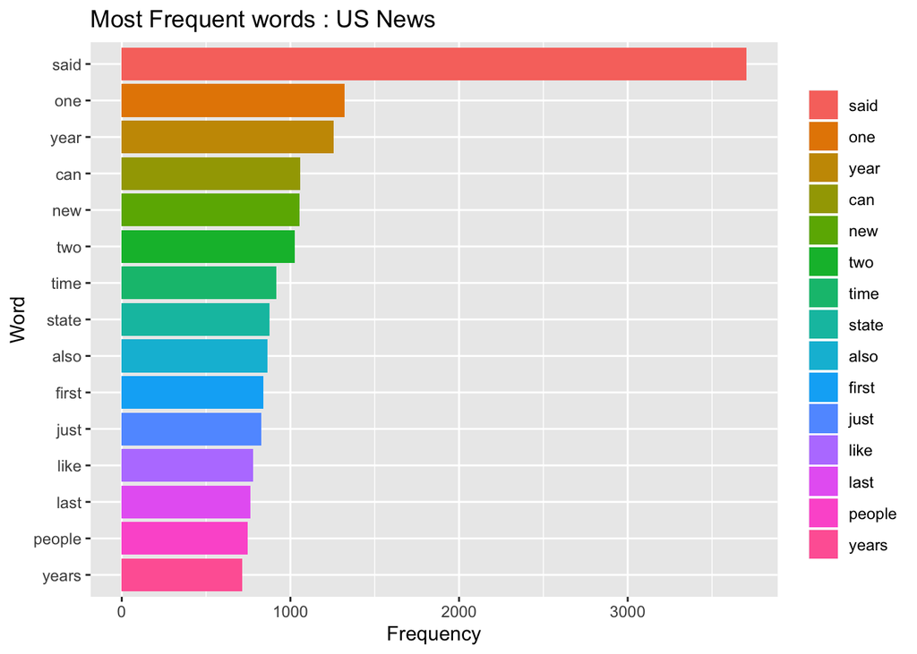

```r
    US_news_most_used_word <- high_freq_words(US_news_corpus)
    US_news_most_used_word1<- US_news_most_used_word[1:15,]

    p<-ggplot(data=US_news_most_used_word1, aes(x=reorder(word,Frequency), y=Frequency,
                    fill=factor(reorder(word,-Frequency))))+ geom_bar(stat="identity")
    p + xlab("Word") +labs(title = "Most Frequent words : US News") +theme(legend.title=element_blank()) + coord_flip()
```

```r
## en_US.blogs.txt High frequency words
    US_blogs_corpus <- make_Corpus(blogs_sample)
    US_blogs_corpus <- clean_corp(US_blogs_corpus)
```

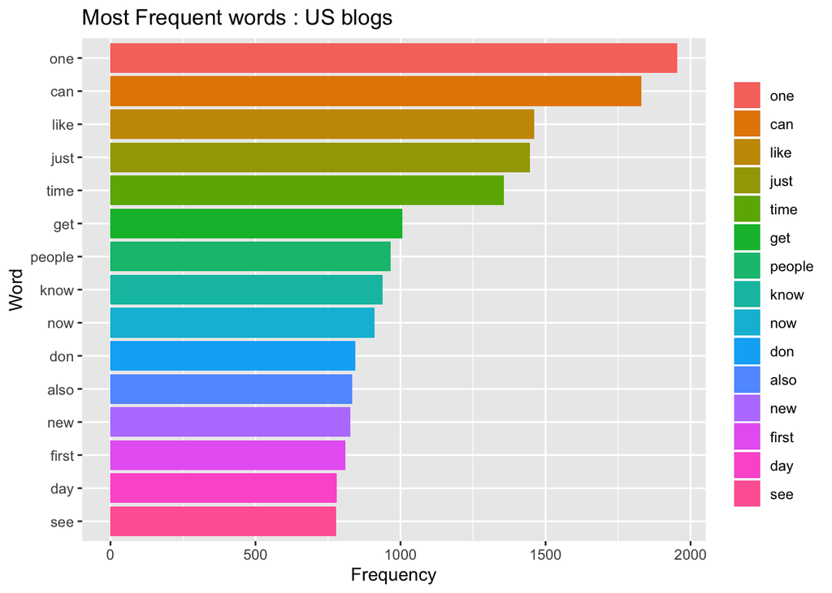

```r
    US_blogs_most_used_word <- high_freq_words(US_blogs_corpus)
    US_blogs_most_used_word1<- US_blogs_most_used_word[1:15,]

    p<-ggplot(data=US_blogs_most_used_word1, aes(x=reorder(word,Frequency), y=Frequency,
                    fill=factor(reorder(word,-Frequency))))+ geom_bar(stat="identity")
    p + xlab("Word") +labs(title = "Most Frequent words : US blogs") +theme(legend.title=element_blank()) + coord_flip()
```

```r
    ## en_US.twitter.txt High frequency words
    twitter_corpus <- make_Corpus(twitter_sample)
    twitter_corpus <- clean_corp(twitter_corpus)
```

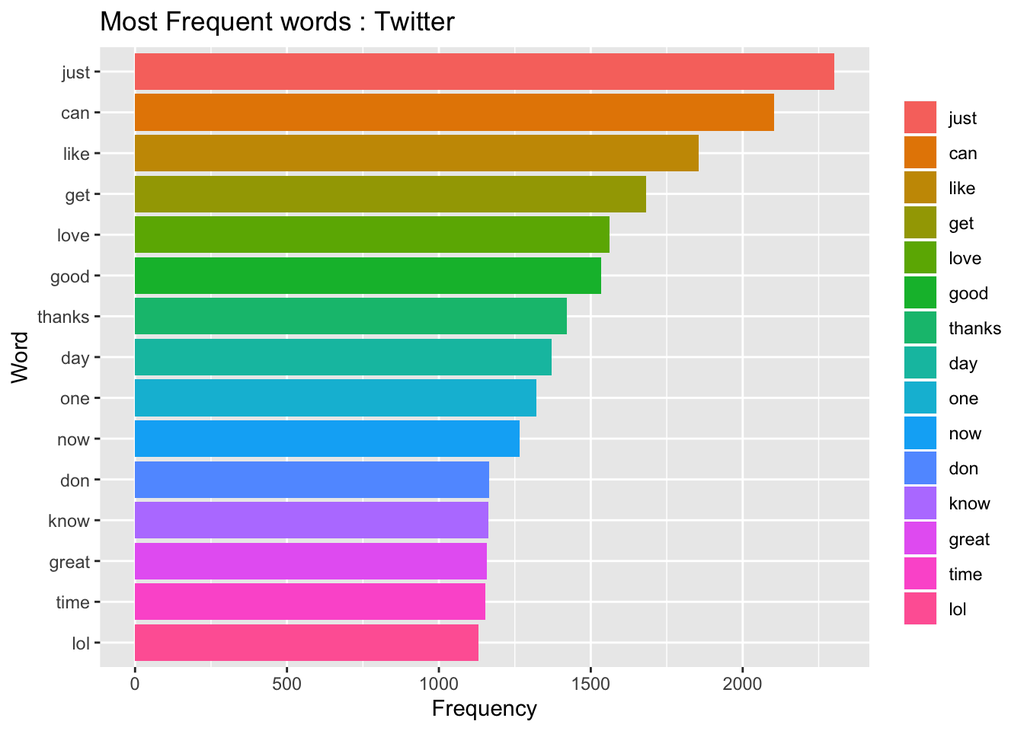

```r
    twitter_most_used_word <- high_freq_words(twitter_corpus)
    twitter_most_used_word1<- twitter_most_used_word[1:15,]

    p<-ggplot(data=twitter_most_used_word1, aes(x=reorder(word,Frequency), y=Frequency,
                    fill=factor(reorder(word,-Frequency))))+ geom_bar(stat="identity")
    p + xlab("Word") +labs(title = "Most Frequent words : Twitter") +theme(legend.title=element_blank()) + coord_flip()
```

## Generating the Word Cloud

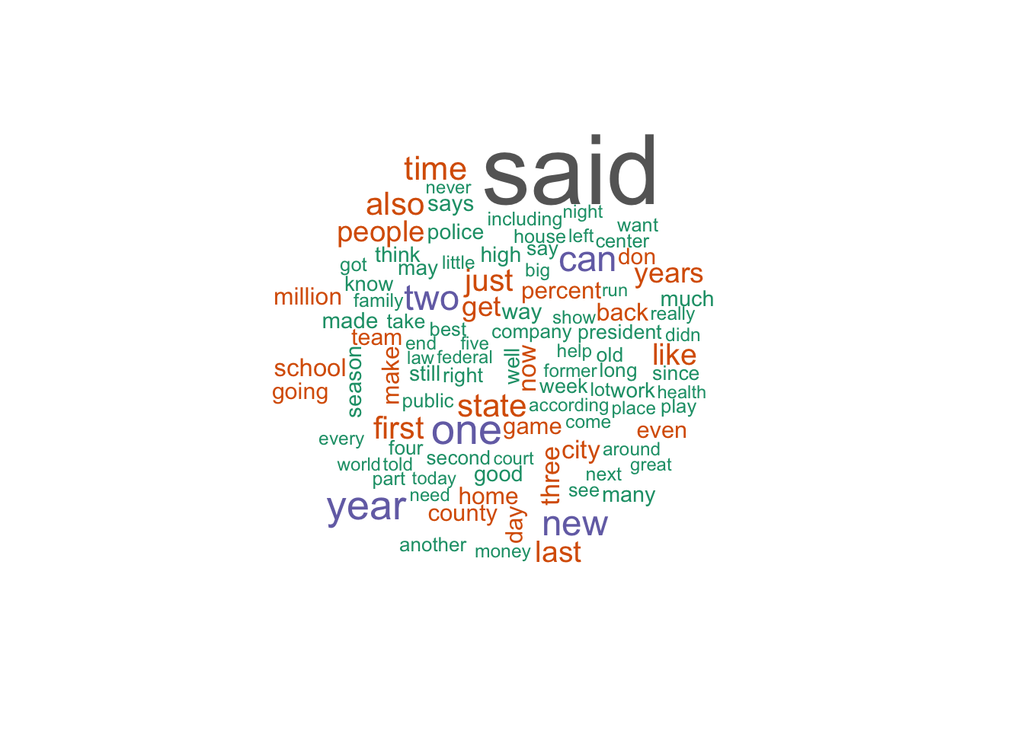

```r
## US News Word Cloud
    wordcloud(US_news_most_used_word$word[1:100], US_news_most_used_word$Frequency[1:100],
              colors=brewer.pal(8, "Dark2"))
```

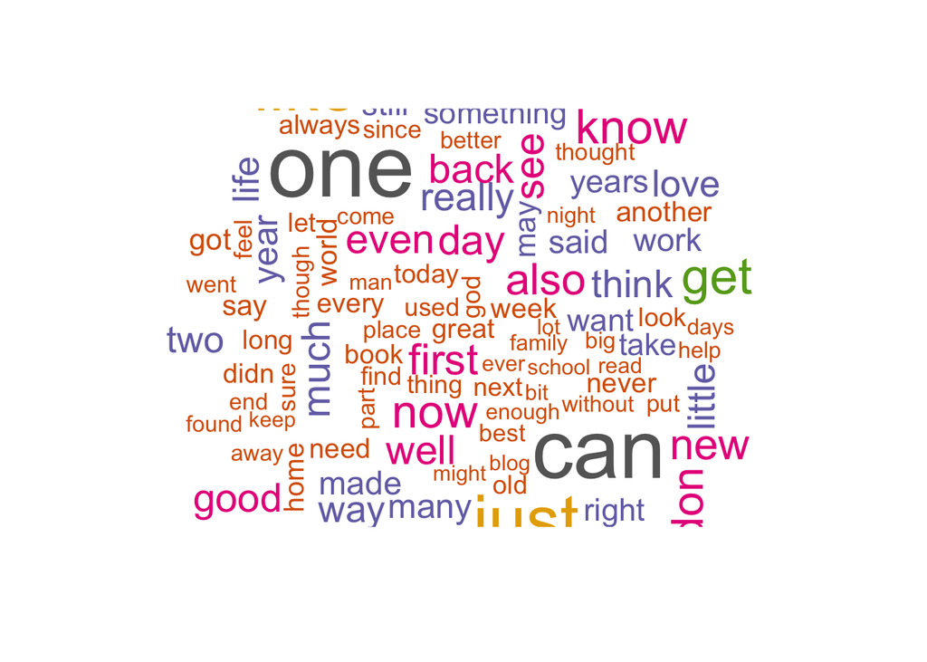

```r
## US Blogs Word Cloud
    wordcloud(US_blogs_most_used_word$word[1:100], US_blogs_most_used_word$Frequency[1:100],
              colors=brewer.pal(8, "Dark2"))
```

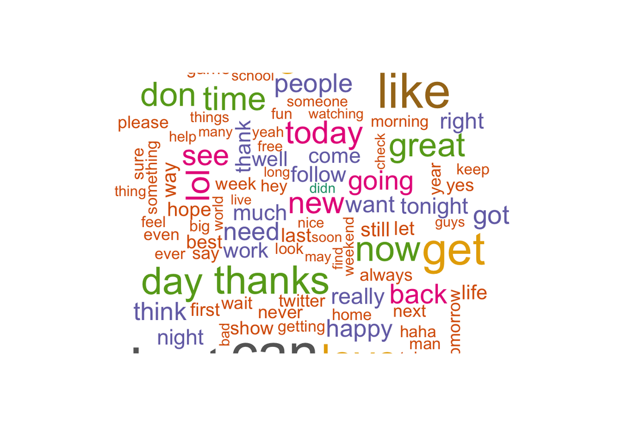

```r
## US Twitter Word Cloud
    wordcloud(twitter_most_used_word$word[1:100], twitter_most_used_word$Frequency[1:100],
              colors=brewer.pal(8, "Dark2"))
```

## Word Analysis

For the Data analysis of text document we need to create a bag of word matrices with Unigram, Bigram, Trigrams. These Ngram model set improve the predictabily of the data analysis.

```r
## news High frequency words
    US_News_tokens<- tokens(news_sample,what ="word", remove_numbers = TRUE,
                            remove_punct = TRUE, remove_separators = TRUE, remove_symbols =TRUE )
    US_News_tokens <- tokens_tolower(US_News_tokens)
    US_News_tokens <- tokens_select(US_News_tokens, stopwords(),selection ="remove")

    US_News_unigram <- tokens_ngrams(US_News_tokens, n=1)  ## unigram
    US_News_unigram.dfm <- dfm(US_News_unigram, tolower =TRUE, remove = stopwords("english"),
                              remove_punct = TRUE)

    US_News_bigram <- tokens_ngrams(US_News_tokens, n=2)  ## bigram
    US_News_bigram.dfm <- dfm(US_News_bigram, tolower =TRUE, remove = stopwords("english"),
                              remove_punct = TRUE)

    US_News_trigram <- tokens_ngrams(US_News_tokens, n=3)  ## trigram
    US_News_trigram.dfm <- dfm(US_News_trigram, tolower =TRUE, remove = stopwords("english"),
                              remove_punct = TRUE)
    topfeatures(US_News_unigram.dfm, 20)  # 20 top US News Unigram words
```

```
##   said    one    new    two    can   also   year   time   just  first
##   3704   1228   1045    917    885    864    855    831    826    763
##   last  state   like people  years    get    now school   make  three
##    759    757    751    727    712    691    580    522    520    513
```

```r
    topfeatures(US_News_trigram.dfm, 20)  # 20 top US News Trigram words
```

```
##    president_barack_obama             two_years_ago
##                        30                        22
##             new_york_city           cents_per_share
##                        15                        15
##        gov_chris_christie           st_louis_county
##                        15                        14
##      superior_court_judge             two_weeks_ago
##                        12                        12
## attorney_general's_office              world_war_ii
##                        10                        10
##            five_years_ago          first_time_since
##                        10                         9
##   chief_executive_officer            el_camino_real
##                         8                         8
##         los_angeles_times        health_care_reform
##                         8                         8
##         million_cents_per     major_league_baseball
##                         8                         8
##         st_charles_county      dow_jones_industrial
##                         8                         8
```

```r
## blog High frequency words
    US_blogs_tokens<- tokens(blogs_sample,what ="word", remove_numbers = TRUE,
                            remove_punct = TRUE, remove_separators = TRUE, remove_symbols =TRUE )
    US_blogs_tokens <- tokens_tolower(US_blogs_tokens)
    US_blogs_tokens <- tokens_select(US_blogs_tokens, stopwords(),selection ="remove")

    US_blogs_unigram <- tokens_ngrams(US_blogs_tokens, n=1)  ## unigram
    US_blogs_unigram.dfm <- dfm(US_blogs_unigram, tolower =TRUE, remove = stopwords("english"),
                              remove_punct = TRUE)

    US_blogs_bigram <- tokens_ngrams(US_blogs_tokens, n=2)  ## bigram
    US_blogs_bigram.dfm <- dfm(US_blogs_bigram, tolower =TRUE, remove = stopwords("english"),
                              remove_punct = TRUE)

    US_blogs_trigram <- tokens_ngrams(US_blogs_tokens, n=3)  ## tiigram
    US_blogs_trigram.dfm <- dfm(US_blogs_trigram, tolower =TRUE, remove = stopwords("english"),
                              remove_punct = TRUE)
    topfeatures(US_blogs_unigram.dfm, 20)  # 20 top US blogs Unigram words
```

```
##    one    can   just   like   time    get people   know    now   also
##   1896   1506   1441   1431   1313   1007    942    936    906    833
##    new  first    see   even    day     us   back   much   good really
##    824    802    776    765    753    739    735    728    723    721
```

```r
    topfeatures(US_blogs_bigram.dfm, 20)  # 20 top US blogs Bigram words
```

```
##       can_see   even_though     years_ago    first_time      new_york
##            84            79            78            74            73
##     last_year     feel_like     right_now     last_week     one_thing
##            72            70            66            61            55
##     make_sure    little_bit       one_day     every_day    looks_like
##            54            52            51            48            48
##     long_time    last_night       can_get united_states      year_old
##            47            47            46            44            42
```

```r
    topfeatures(US_blogs_trigram.dfm, 20)  # 20 top US blogs Trigram words
```

```
##       italian_people_italy             new_york_times
##                         17                         14
##              new_york_city              two_years_ago
##                         13                         10
##        big_fat_independent      fat_independent_movie
##                         10                         10
##          lord_jesus_christ            spend_much_time
##                          6                          6
##              long_time_ago       incorporated_item_pp
##                          6                          6
##               one_year_ago university_chicago_chicago
##                          5                          5
##   chicago_chicago_illinois               can_see_just
##                          5                          5
##           first_time_since             blah_blah_blah
##                          5                          5
##               well_can_see           know_many_people
##                          4                          4
##            today_first_day            since_last_post
##                          4                          4
```

```r
## twitter Ngram words
    twitter_tokens<- tokens(twitter_sample,what ="word", remove_numbers = TRUE,
                            remove_punct = TRUE, remove_separators = TRUE, remove_symbols =TRUE )
    twitter_tokens <- tokens_tolower(twitter_tokens)
    twitter_tokens <- tokens_select(twitter_tokens, stopwords(),selection ="remove")

    twitter_unigram <- tokens_ngrams(twitter_tokens, n=1)  ## unigram
    twitter_unigram.dfm <- dfm(twitter_unigram, tolower =TRUE, remove = stopwords("english"),
                              remove_punct = TRUE)

    twitter_bigram <- tokens_ngrams(twitter_tokens, n=2)  ## bigram
    twitter_bigram.dfm <- dfm(twitter_bigram, tolower =TRUE, remove = stopwords("english"),
                              remove_punct = TRUE)

    twitter_trigram <- tokens_ngrams(twitter_tokens, n=3)  ## trigram
    twitter_trigram.dfm <- dfm(twitter_trigram, tolower =TRUE, remove = stopwords("english"),
                              remove_punct = TRUE)
    topfeatures(twitter_unigram.dfm, 20)  # 20 top Unigram words
```

```
##   just   like    get   love   good thanks    can     rt    day    one
##   2296   1845   1675   1548   1529   1420   1395   1345   1332   1289
##    now   know  great   time      u    lol     go    new  today    see
##   1261   1156   1154   1135   1134   1123   1117   1046   1034    976
```

```r
    topfeatures(twitter_bigram.dfm, 20)  # 20 top Bigram words
```

```
##        right_now       last_night  looking_forward        feel_like
##              248              162              133              119
##   happy_birthday     good_morning        good_luck    thanks_follow
##              115              115              107              106
##         just_got       looks_like         let_know          can_get
##              105               86               84               80
##        thanks_rt      follow_back      sounds_like thanks_following
##               71               70               67               65
##       first_time        great_day         just_saw        make_sure
##               64               64               61               61
```

```r
    topfeatures(twitter_trigram.dfm, 20)  # 20 top  Trigram words
```

```
##     happy_mother's_day            let_us_know         happy_new_year
##                     34                     31                     26
##          cinco_de_mayo      happy_mothers_day                  x_x_x
##                     23                     22                     20
##          just_got_back    hope_everyone_great         keep_good_work
##                     13                     12                     11
##            yes_yes_yes looking_forward_seeing         happy_hump_day
##                     11                      9                      9
##  happy_valentine's_day         love_love_love    thanks_following_us
##                      9                      8                      8
##      shoes_shoes_shoes         today_last_day     follow_back_please
##                      8                      8                      8
##         happy_cinco_de          know_can_help
##                      7                      7
```

## Interesting findings that you amassed so far

I have gone through the multiple literatures and youtube vidios on Text mining. Learned almost everything new specifically “quanteda” library. How text data set will get exploded with different ngrams and Bag of words. Looks like quanteda library is useful in generating the text analytics. Which very fast compare to TM library.

## Get feedback on your plans for creating a prediction algorithm and Shiny app.

### Plan of Approach:

- Tockenization and bag of words with multiple Ngrams.
- Due to limited resource (hardware and computational), analysis was done on a same sample to build the shiny app.

### Feedback:

- Looking forward for the feedback and suggestion to improve the analysis.